# RNA-seq_opdracht1

2026-03-23

```r
knitr::opts_chunk$set(echo = TRUE, eval = FALSE)
library(tidyverse)
library(Rsubread)
```

# Onderdeel Les 1

## Onderdeel 1a

- *Schrijf een korte introductie voor de Rmarkdown met daarin in eigen woorden het doel van jouw onderzoek/analyses.*

Deze formatieve opdracht is gebaseerd op onderzoek naar fibroblasten afkomstig van de menselijke huid en daaruit geïnduceerde pluripotente stamcellen(iPSC). Van de twee proefpersonen zijn er twee cellijnen verkregen. De vier transcriptiefactoren, namelijk MYC, OCT3/4, SOX2 en KLF4, worden tot overexpressie gebracht om iPSC te maken.

In de eerste deel van de formatieve opdracht worden volgende analyses uitgevoerd:

## Opdracht 1b:

- *Stel dat de sample identifiers in een textfile staan. Schrijf een bash script voor het downloaden van de fastq files voor alle identifiers. Zorg ervoor dat dit script een for loop bevat, zodat je niet voor elke fastq file een aparte regel code hoeft te schrijven.*

```bash
for id in $(cat "$text.txt")
do
    fastq-dump --split-3 --outdir "$outdirsra" --gzip "$id"
done
```

## Onderdeel 1d

- *Schrijf code voor het uitvoeren van de alignment met de Rsubread package. Voor de alignment kun je gebruik maken van de hg38 genome index die is te vinden /home/daur2/rnaseq/hg38_index/*
- *NB: voer dit script niet uit, want de alignment is al voor jullie uitgevoerd!*

```r
# Create object with location of fastq files
fastq_dir <- "./rnaseq_airway/fastq/"

# Create object with basename of index files
hg38_index <- "./hg38_index/hg38_index"

# Create object with output dir for bam files
bam_dir <- "./rnaseq_airway/bam/"

# Create a vector with sample numbers
samples <- list.files(fastq_dir, pattern = "_[12].fastq.gz") %>%
  str_remove(pattern = "_[12].fastq.gz") %>%
  unique()

# Align the reads in the fastq files
alignment_statistics <- align(

  index = hg38_index,
  readfile1 = paste0(fastq_dir, samples, "_1.fastq.gz"),
  readfile2 = paste0(fastq_dir, samples, "_2.fastq.gz"),
  type = "rna", input_format = "gzFASTQ", output_format = "BAM",
  output_file = paste0(bam_dir, samples, ".bam"),

  # report only uniquely mapping reads
  unique = TRUE,

  # number of CPU threads
  nthreads = 10

)

# Store the alignment statistics as R object
saveRDS(alignment_statistics, file = paste0(bam_dir, "alignment_statistics.rds"))
```

## Onderdeel 1e

- *In de directory met de bam files kun je ook het bestand ‘alignment_statistics.rds’ vinden. Gebruik dit bestand om een grouped bar graph te maken met daarin voor elk sample zowel het percentage mapped fragments als het percentage unmapped fragments.*

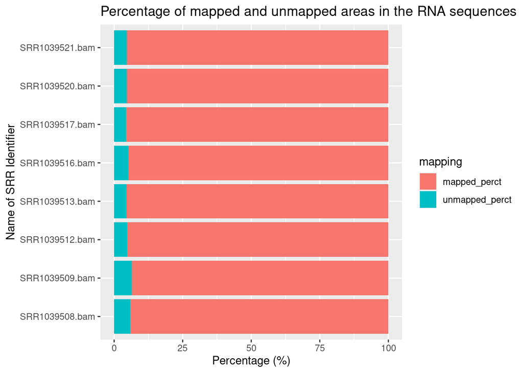

```r
#Step 1 RDS to tibble
Alignment<-readRDS(file = "alignment_statistics.rds") %>% t() %>% as_tibble()
alignment_statistics<-readRDS("alignment_statistics.rds")

#Step 2 add columns
Alignment<-Alignment %>%
  mutate(Naam = colnames(alignment_statistics), .before = Total_fragments,
         mapped_perct = Mapped_fragments/Total_fragments*100,
unmapped_perct = Unmapped_fragments/Total_fragments*100)

#Step 3 make data tidy for barplot
Alignment<-Alignment %>% pivot_longer(cols = c("mapped_perct", "unmapped_perct"),
                           names_to = "mapping", values_to = "percentage")

#Step 4 plot the data
Alignment %>% ggplot(aes(x = percentage, y = Naam, fill = mapping))+
  geom_col()+
  labs(title = "Percentage of mapped and unmapped areas in the RNA sequences",
       x = "Percentage (%)", y = "Name of SRR Identifier")
```

- *Wat is je conclusie op basis van deze grafiek?*

Ongeveer 95% van de RNA sequenties zijn mapped en 5% is unmapped. Er zijn veel unieke reads die matchen met de reference genome en weinig die niet goed kunnen matchen.